# Lab 5

2019-02-22

## Exercise 1

Give a description of what the last plot means in relation to the lasso coefficient estimates and the lasso regularization parameter: What do the lines represent? How does the lasso regularization parameter vary with the x-axis?

```r
library(lars)
```

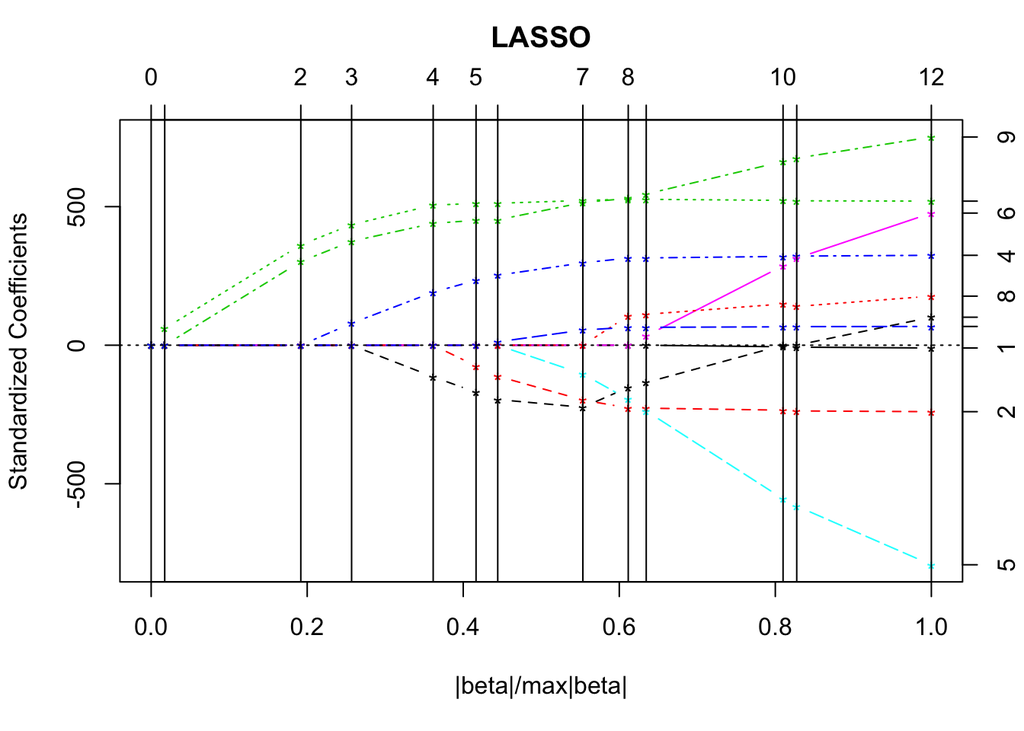

```r
data(diabetes)
object <- lars(x = diabetes$x, y = diabetes$y)
plot(object)
```

Answer:

Each line in the plot shows us how any coefficient (say $\beta_3$), changes with the ratio of the absolute value of that coefficient to the maximum of the absolute value of that coefficient, which could coincide with the coefficient retrieved via OLS. This plot visualizes the above for all coefficients. Further, the above axis shows us how many variables the lasso regression has “selected”, at any point on the x-axis. For example, we see that there are no non-zero coefficient when $\frac{\mid\beta\mid}{\max\mid\beta\mid} = 0.0$ and there are 2 non-zero coefficients when $\frac{\mid\beta\mid}{\max\mid\beta\mid} = 0.2$. This means the lasso has selected 2 variables.

The lasso regularization parameter decreases with as we move along the x-axis. We can see this by looking at the number of coefficients selected. At 0, the regularization parameter is extremely high and all coefficients are set to 0. At 1.0 all variables are selcted and most variables are set to their OLS coefficient.

## Exercise 2

The black dashed line in the last plot is not monotone: It first decreases and then starts to increase. What does this mean or what could be a reason for this?

The black dashed line starts increasing when another variable (shown by the red line) is selected into the lasso regression. This is because of the collinearity structure between the different variables. As we now add another variable that correlates with the variable shown by the black dashed line, we expect the coefficient to change. Intuitively, we can imagine that a specific coefficient estimate is biased downwards but after controlling for some variables, the coefficient would increase and be unbiased.

Imagine we are interested in how income varies with education. We run the regression,

$income_i = \beta_0 + \beta_1educ_i + \epsilon_i$.

We expect $\beta_1$ to be positive as people with higher education have higher income. However, after we control for ability, we expect the coefficient on education to go down as $cov(educ,abil) > 0$ and $cov(income,abil) > 0$. In the same way, when lasso selects another variable, the correlation structure changes and some coefficients may change.

## Exercise 3

Which 2 predictors are selected into the model first by lasso?

```r
coef(object)
```

```
##              age        sex       bmi       map        tc       ldl
##  [1,]   0.000000    0.00000   0.00000   0.00000    0.0000   0.00000
##  [2,]   0.000000    0.00000  60.11927   0.00000    0.0000   0.00000
##  [3,]   0.000000    0.00000 361.89461   0.00000    0.0000   0.00000
##  [4,]   0.000000    0.00000 434.75796  79.23645    0.0000   0.00000
##  [5,]   0.000000    0.00000 505.65956 191.26988    0.0000   0.00000
##  [6,]   0.000000  -74.91651 511.34807 234.15462    0.0000   0.00000
##  [7,]   0.000000 -111.97855 512.04409 252.52702    0.0000   0.00000
##  [8,]   0.000000 -197.75650 522.26485 297.15974 -103.9462   0.00000
##  [9,]   0.000000 -226.13366 526.88547 314.38927 -195.1058   0.00000
## [10,]   0.000000 -227.17580 526.39059 314.95047 -237.3410  33.62827
## [11,]  -5.718948 -234.39762 522.64879 320.34255 -554.2663 286.73617
## [12,]  -7.011245 -237.10079 521.07513 321.54903 -580.4386 313.86213
## [13,] -10.012198 -239.81909 519.83979 324.39043 -792.1842 476.74584
##             hdl      tch      ltg      glu
##  [1,]    0.0000   0.0000   0.0000  0.00000
##  [2,]    0.0000   0.0000   0.0000  0.00000
##  [3,]    0.0000   0.0000 301.7753  0.00000
##  [4,]    0.0000   0.0000 374.9158  0.00000
##  [5,] -114.1010   0.0000 439.6649  0.00000
##  [6,] -169.7114   0.0000 450.6674  0.00000
##  [7,] -196.0454   0.0000 452.3927 12.07815
##  [8,] -223.9260   0.0000 514.7495 54.76768
##  [9,] -152.4773 106.3428 529.9160 64.48742
## [10,] -134.5994 111.3841 545.4826 64.60667
## [11,]    0.0000 148.9004 663.0333 66.33096
## [12,]    0.0000 139.8579 674.9366 67.17940
## [13,]  101.0446 177.0642 751.2793 67.62539
```

Answer:

The first two variables that are selected are $bmi$ and $ltg$.

## Exercise 4

What does the argument nstart of the function kmeans represent? Why is it better to use nstart = 25 than the function’s default of nstart = 1?

For each $k$, the option nstart specifies that the $k$-means algorithm will be repeated n times, each starting with k random initial centroids. $n$-start = 25 will attempt 25 initial configurations of centriods and best one will be chosen. This is better than setting $n$-start to 1 as the first initial configuration, which is a random guess, may not be the best one.

## Exercise 5

Consider the data with as only variables the 2 that the lasso selected in Exercise 3. Pick a number k of clusters for your k-means analysis. Base your answer on the within sum of squares (WSS).

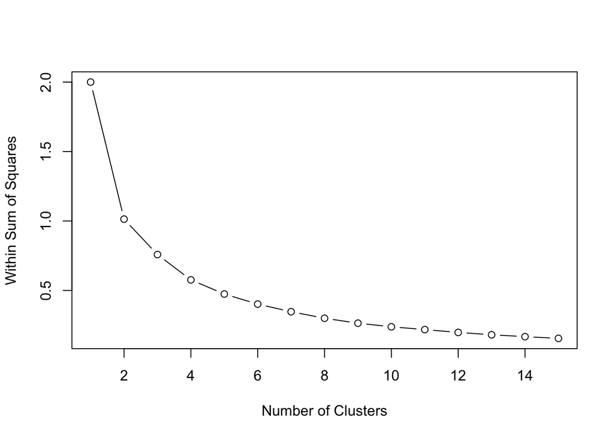

```r
df <- diabetes$x

df <- data.frame(bmi = df[,3],
                 ltg = df[,9])
wss <- numeric(15)
for (k in 1:15) {
  wss[k] <- sum(kmeans(df, centers=k, nstart=25)$withinss)
}

plot(1:15, wss, type="b", xlab="Number of Clusters", ylab="Within Sum of Squares")
```

```r
# eyeballing this, k = 3 is the elbow of the wss curve

final_km <- kmeans(df,3, nstart=30)
```

Answer:

We picked k = 3, which means that there will be 3 clusters. This is because k = 3 corresponds with the elbow of the WSS curve. Intuitively, we know that WSS always decreases with the number of clusters. The returns, measured by a decrease in WSS, dimishes significantly after k = 3. Thus, we pick 3 clusters.

## Exercise 6

Visualize the results of the k-means analysis using the k chosen in Exercise 5. A suitable visualization is for instance Figure 4-6 from the textbook. If you follow the code on page 216 of the textbook, please be aware that the argument show_guide of the function ggplot has been deprecated and should be replaced by show.legend.

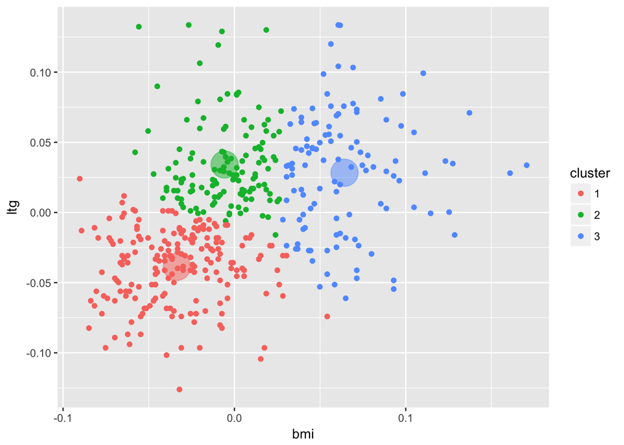

```r
df$cluster <- factor(final_km$cluster)
centers <- as.data.frame(final_km$centers)

library(ggplot2)
ggplot(data = df,
        aes(x = bmi, y = ltg, color = cluster)) +
  geom_point() +
  theme(legend.position="right") +
  geom_point(data=centers,
             aes(x=bmi, y=ltg,
                 color=as.factor(c(1,2,3))),
             size=10, alpha=0.5, show.legend = FALSE)
```

## Exercise 7

Provide an interpretation of what each of the k clusters obtained in Exercise 6 mean.